# (Prosper Loan Dataset)

## by (Praise Onyehanere)

Prosper is a Fintech company.A place where you can borrow and lend a money. The power to send is limitless. Modern “Fintech companies, as they’ve come to be called, are easing payment processes, reducing fraud, saving users money and promoting financial planning.”

## Preliminary Wrangling

I first skimmed through the dataset, which has 81 variables, Since most of these parameter were new to me but I was interested in learning about them and explore their impact on Loan Yeild, amount ,borrower rate etc . I initially planned on making a subset of the data, but instead opted for using the entire dataset in case I got any new ideas midway through my exploration.

```python
# import all packages and set plots to be embedded inline
import numpy as np
import pandas as pd
import matplotlib.pyplot as plt
# import seaborn as sb
import seaborn as sns
%matplotlib inline


#Plotting
import matplotlib.pyplot as plt

%matplotlib inline
sns.set_style("whitegrid")
sns.set_context({"figure.figsize": (11.69, 8.27)})
```

```python
# load in the dataset into a pandas dataframe, print statistics
# Reading the Dataset
df_0 = original_data = pd.read_csv("prosperLoanData.csv")
pd.set_option("display.max_columns", len(df_0.columns))
df_0.head()
```

|  | ListingKey | ListingNumber | ListingCreationDate | CreditGrade | Term | LoanStatus | ClosedDate | BorrowerAPR | BorrowerRate | LenderYield | EstimatedEffectiveYield | EstimatedLoss | EstimatedReturn | ProsperRating (numeric) | ProsperRating (Alpha) | ProsperScore | ListingCategory (numeric) | BorrowerState | Occupation | EmploymentStatus | EmploymentStatusDuration | IsBorrowerHomeowner | CurrentlyInGroup | GroupKey | DateCreditPulled | CreditScoreRangeLower | CreditScoreRangeUpper | FirstRecordedCreditLine | CurrentCreditLines | … |
| --- | --- | --- | --- | --- | --- | --- | --- | --- | --- | --- | --- | --- | --- | --- | --- | --- | --- | --- | --- | --- | --- | --- | --- | --- | --- | --- | --- | --- | --- | --- |
| 0 | 1021339766868145413AB3B | 193129 | 2007-08-26 19:09:29.263000000 | C | 36 | Completed | 2009-08-14 00:00:00 | 0.16516 | 0.1580 | 0.1380 | NaN | NaN | NaN | NaN | NaN | NaN | 0 | CO | Other | Self-employed | 2.0 | True | True | NaN | 2007-08-26 18:41:46.780000000 | 640.0 | 659.0 | 2001-10-11 00:00:00 | 5.0 | … |
| 1 | 10273602499503308B223C1 | 1209647 | 2014-02-27 08:28:07.900000000 | NaN | 36 | Current | NaN | 0.12016 | 0.0920 | 0.0820 | 0.07960 | 0.0249 | 0.05470 | 6.0 | A | 7.0 | 2 | CO | Professional | Employed | 44.0 | False | False | NaN | 2014-02-27 08:28:14 | 680.0 | 699.0 | 1996-03-18 00:00:00 | 14.0 | … |
| 2 | 0EE9337825851032864889A | 81716 | 2007-01-05 15:00:47.090000000 | HR | 36 | Completed | 2009-12-17 00:00:00 | 0.28269 | 0.2750 | 0.2400 | NaN | NaN | NaN | NaN | NaN | NaN | 0 | GA | Other | Not available | NaN | False | True | 783C3371218786870A73D20 | 2007-01-02 14:09:10.060000000 | 480.0 | 499.0 | 2002-07-27 00:00:00 | NaN | … |
| 3 | 0EF5356002482715299901A | 658116 | 2012-10-22 11:02:35.010000000 | NaN | 36 | Current | NaN | 0.12528 | 0.0974 | 0.0874 | 0.08490 | 0.0249 | 0.06000 | 6.0 | A | 9.0 | 16 | GA | Skilled Labor | Employed | 113.0 | True | False | NaN | 2012-10-22 11:02:32 | 800.0 | 819.0 | 1983-02-28 00:00:00 | 5.0 | … |
| 4 | 0F023589499656230C5E3E2 | 909464 | 2013-09-14 18:38:39.097000000 | NaN | 36 | Current | NaN | 0.24614 | 0.2085 | 0.1985 | 0.18316 | 0.0925 | 0.09066 | 3.0 | D | 4.0 | 2 | MN | Executive | Employed | 44.0 | True | False | NaN | 2013-09-14 18:38:44 | 680.0 | 699.0 | 2004-02-20 00:00:00 | 19.0 | … |

```python
# I find  credit ScoreRangeUpper same as CreditScoreRangeLower with slight offset thats why to take the affect of both i have taken the mean value.

df_0['CreditScoreRangeAvg']=(df_0['CreditScoreRangeUpper']+df_0['CreditScoreRangeLower'])/2
df_0['CreditScoreRangeAvg'].head()
# CreditScoreRangeAvg
```

```
0    649.5
1    689.5
2    489.5
3    809.5
4    689.5
Name: CreditScoreRangeAvg, dtype: float64
```

```python
# high-level overview of data shape and composition
print("shape: " ,df_0.shape)
print( df_0.dtypes)
```

```
shape:  (113937, 82)
ListingKey                      object
ListingNumber                    int64
ListingCreationDate             object
CreditGrade                     object
Term                             int64
                                ...
Recommendations                  int64
InvestmentFromFriendsCount       int64
InvestmentFromFriendsAmount    float64
Investors                        int64
CreditScoreRangeAvg            float64
Length: 82, dtype: object
```

```python
# high-level overview of data shape and composition
df_0.describe()
```

|  | ListingNumber | Term | BorrowerAPR | BorrowerRate | LenderYield | EstimatedEffectiveYield | EstimatedLoss | EstimatedReturn | ProsperRating (numeric) | ProsperScore | ListingCategory (numeric) | EmploymentStatusDuration | CreditScoreRangeLower | CreditScoreRangeUpper | CurrentCreditLines | OpenCreditLines | TotalCreditLinespast7years | OpenRevolvingAccounts | OpenRevolvingMonthlyPayment | InquiriesLast6Months | TotalInquiries | CurrentDelinquencies | AmountDelinquent | DelinquenciesLast7Years | PublicRecordsLast10Years | PublicRecordsLast12Months | RevolvingCreditBalance | BankcardUtilization | AvailableBankcardCredit | … |
| --- | --- | --- | --- | --- | --- | --- | --- | --- | --- | --- | --- | --- | --- | --- | --- | --- | --- | --- | --- | --- | --- | --- | --- | --- | --- | --- | --- | --- | --- | --- |
| count | 1.139370e+05 | 113937.000000 | 113912.000000 | 113937.000000 | 113937.000000 | 84853.000000 | 84853.000000 | 84853.000000 | 84853.000000 | 84853.000000 | 113937.000000 | 106312.000000 | 113346.000000 | 113346.000000 | 106333.000000 | 106333.000000 | 113240.000000 | 113937.00000 | 113937.000000 | 113240.000000 | 112778.000000 | 113240.000000 | 106315.000000 | 112947.000000 | 113240.000000 | 106333.000000 | 1.063330e+05 | 106333.000000 | 106393.000000 | … |
| mean | 6.278857e+05 | 40.830248 | 0.218828 | 0.192764 | 0.182701 | 0.168661 | 0.080306 | 0.096068 | 4.072243 | 5.950067 | 2.774209 | 96.071582 | 685.567731 | 704.567731 | 10.317192 | 9.260164 | 26.754539 | 6.96979 | 398.292161 | 1.435085 | 5.584405 | 0.592052 | 984.507059 | 4.154984 | 0.312646 | 0.015094 | 1.759871e+04 | 0.561309 | 11210.225447 | … |
| std | 3.280762e+05 | 10.436212 | 0.080364 | 0.074818 | 0.074516 | 0.068467 | 0.046764 | 0.030403 | 1.673227 | 2.376501 | 3.996797 | 94.480605 | 66.458275 | 66.458275 | 5.457866 | 5.022644 | 13.637871 | 4.63097 | 447.159711 | 2.437507 | 6.429946 | 1.978707 | 7158.270157 | 10.160216 | 0.727868 | 0.154092 | 3.293640e+04 | 0.317918 | 19818.361309 | … |
| min | 4.000000e+00 | 12.000000 | 0.006530 | 0.000000 | -0.010000 | -0.182700 | 0.004900 | -0.182700 | 1.000000 | 1.000000 | 0.000000 | 0.000000 | 0.000000 | 19.000000 | 0.000000 | 0.000000 | 2.000000 | 0.00000 | 0.000000 | 0.000000 | 0.000000 | 0.000000 | 0.000000 | 0.000000 | 0.000000 | 0.000000 | 0.000000e+00 | 0.000000 | 0.000000 | … |
| 25% | 4.009190e+05 | 36.000000 | 0.156290 | 0.134000 | 0.124200 | 0.115670 | 0.042400 | 0.074080 | 3.000000 | 4.000000 | 1.000000 | 26.000000 | 660.000000 | 679.000000 | 7.000000 | 6.000000 | 17.000000 | 4.00000 | 114.000000 | 0.000000 | 2.000000 | 0.000000 | 0.000000 | 0.000000 | 0.000000 | 0.000000 | 3.121000e+03 | 0.310000 | 880.000000 | … |
| 50% | 6.005540e+05 | 36.000000 | 0.209760 | 0.184000 | 0.173000 | 0.161500 | 0.072400 | 0.091700 | 4.000000 | 6.000000 | 1.000000 | 67.000000 | 680.000000 | 699.000000 | 10.000000 | 9.000000 | 25.000000 | 6.00000 | 271.000000 | 1.000000 | 4.000000 | 0.000000 | 0.000000 | 0.000000 | 0.000000 | 0.000000 | 8.549000e+03 | 0.600000 | 4100.000000 | … |
| 75% | 8.926340e+05 | 36.000000 | 0.283810 | 0.250000 | 0.240000 | 0.224300 | 0.112000 | 0.116600 | 5.000000 | 8.000000 | 3.000000 | 137.000000 | 720.000000 | 739.000000 | 13.000000 | 12.000000 | 35.000000 | 9.00000 | 525.000000 | 2.000000 | 7.000000 | 0.000000 | 0.000000 | 3.000000 | 0.000000 | 0.000000 | 1.952100e+04 | 0.840000 | 13180.000000 | … |
| max | 1.255725e+06 | 60.000000 | 0.512290 | 0.497500 | 0.492500 | 0.319900 | 0.366000 | 0.283700 | 7.000000 | 11.000000 | 20.000000 | 755.000000 | 880.000000 | 899.000000 | 59.000000 | 54.000000 | 136.000000 | 51.00000 | 14985.000000 | 105.000000 | 379.000000 | 83.000000 | 463881.000000 | 99.000000 | 38.000000 | 20.000000 | 1.435667e+06 | 5.950000 | 646285.000000 | … |

### What is the structure of your dataset?

> There are 113,937 Loan listing in the dataset with 81 features . Most variables are numeric in nature, but the variables Prosper RAting,BorrowerState,CurrentlyInGroup are categorical Data variables with the following levels.

> CurrentlyInGroup ——> (True/False) LoanStatus : Current ,Defaulted,Past Due (1-15 days) ,Completed ,Cancelled IncomeVerifiable: $1-24,999, $25,000-49,999, $50,000-74,999, $100,000+,Not displayed

### What is/are the main feature(s) of interest in your dataset?

> The purpose of my EDA is to learn interesting facts from a business Point of View. however this may not restrict me from finding other facts. A lot of relevation will be for understanding borrowing trends aswell.

### What features in the dataset do you think will help support your investigation into your feature(s) of interest?

> There are a lot of Financial terms & feautures that are new to me and I heard about them for the first time, but I will learn new terminolgies few to mention are LoanStatus,EmploymentStatus,IsBorrowerHomeowner,BorrowerRate,CreditSCore,CreditRating,ProsperRating, Term... and many many more.

## Univariate Exploration

> In this section,I start my investigation from understanding about (clients or Customers of Prosper platform) ,Where they reside? what they do? what is their credit Ratings

```python
# Occupation Histogram
```

```python
List_occupations=df_0['Occupation'].value_counts()
order_occupations=List_occupations.index
List_occupations
```

```
Other                          28617
Professional                   13628
Computer Programmer             4478
Executive                       4311
Teacher                         3759
                               ...
Dentist                           68
Student - College Freshman        41
Student - Community College       28
Judge                             22
Student - Technical School        16
Name: Occupation, Length: 67, dtype: int64
```

```python
# extracting list of occupation and making a new data frame  of this list

list_occupations=list(df_0['Occupation'])

df_occupations=pd.DataFrame(list_occupations, columns=['occupation'])
df_occupations.head()
```

|  | occupation |
| --- | --- |
| 0 | Other |
| 1 | Professional |
| 2 | Other |
| 3 | Skilled Labor |
| 4 | Executive |

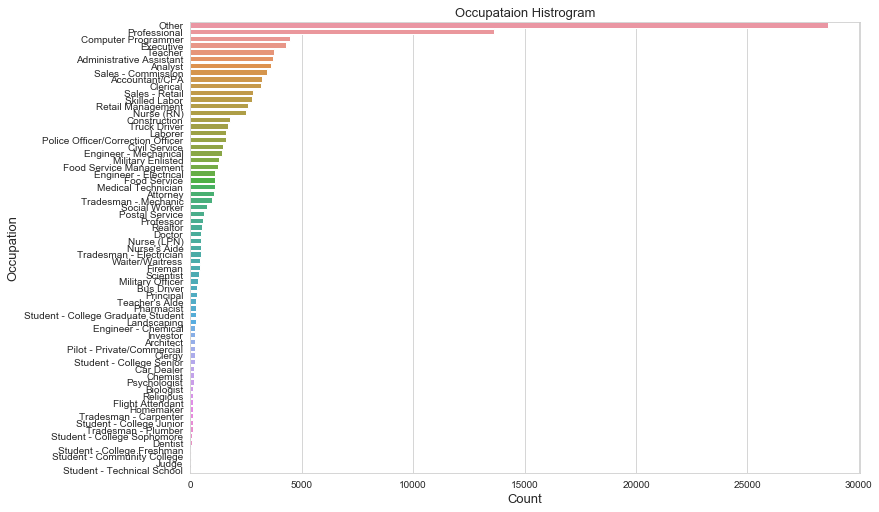

```python
plt.figure(figsize=(12,8.3))
sns.countplot(  y='occupation' ,data = df_occupations, order = order_occupations)
plt.xlabel('Count',fontsize=13)
plt.ylabel('Occupation',fontsize=13)
plt.title('Occupataion Histrogram',fontsize=13)
```

The thing I noticed in this graph were the two bars a distinct from the rest of the occupations i.e 'others' and 'Professionals'. It seems like the people signing up on Prosper are not quite willing to provide their job information, and are opting instead for these two ambiguous options by using 'others' or 'professionals' instead of mentioning precise occupation. Most of the professions have pretty low counts, but the diversity is quite interesting. Among all of them, relatively popular ones include analysts, accountants, computer programmers, teachers and executives,in contrast students of technical school, students of community colleges and Judges avoid using Prosper platform.

Nevertheless Prosper has definitely enabled a wide range of working people to either borrow or invest money.

```python
# States Popularity Plot
```

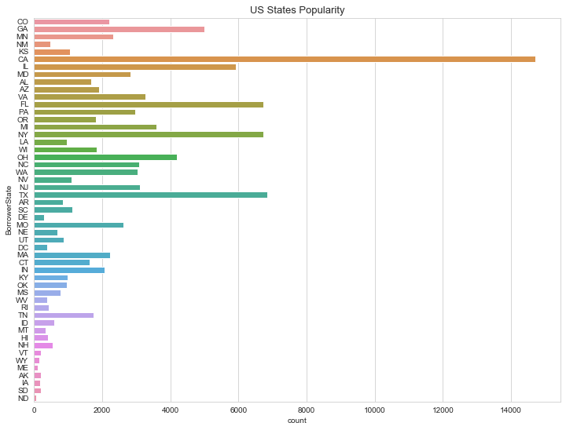

```python
plt.figure(figsize=(12,9))

sns.countplot(y="BorrowerState", data=df_0)
plt.title('US States Popularity',fontsize=13)
```

The Prosper is most popular in CA (14717 browers) from California this is also evidient from the fact that Prosper itself was founded in California- Sansfrancisco . on the other hand Prosper is not used much in North Dakota (only 52 people exploited Prosper)

```python
# Perpose of borrowing Loan
```

```python
# Preparing or Data about the Pupose of Borrowing Loan(assigning names to Categorical nomical Data of listing Categoery)
df_category=df_0
df_category.replace(to_replace={"ListingCategory (numeric)": {0: "Unknown", 1: "Debt", 2: "Reno", 3: "Business", 4: "Personal",
                                                                5: "Student", 6: "Auto", 7: "Other", 8: "Baby", 9: "Boat",
                                                                10: "Cosmetic", 11: "Engagement", 12: "Green", 13: "Household",
                                                                14: "LargePurchase", 15: "Medical", 16: "Motorcycle", 17: "RV",
                                                                18: "Taxes", 19: "Vacation", 20: "Wedding"}}, inplace=True)

df_category.rename(index=str, columns={"ListingCategory (numeric)": "ListingCategory"}, inplace=True)

df_category["ListingCategory"][:10]
```

```
0       Unknown
1          Reno
2       Unknown
3    Motorcycle
4          Reno
5          Debt
6          Debt
7          Reno
8         Other
9         Other
Name: ListingCategory, dtype: object
```

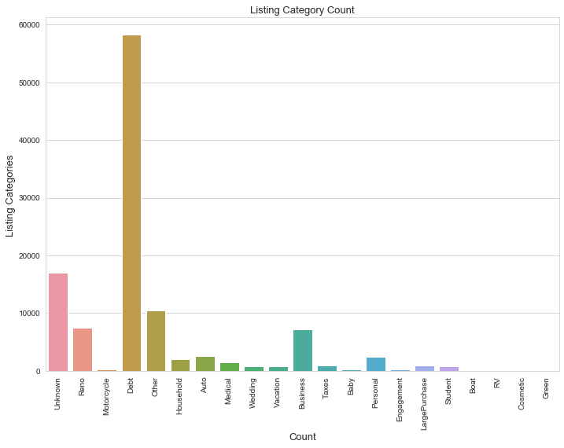

```python
plt.figure(figsize=[ 11.69, 8.27])

sns.countplot(data = df_0, x = 'ListingCategory')
plt.xticks(rotation = 90)

plt.xlabel('Count',fontsize=13)
plt.ylabel('Listing Categories ',fontsize=13)
plt.title("Listing Category Count",fontsize=13)
```

##### Debt refinancing i.e. taking out one loan to pay off many other Loans seem to be most prominent purpose of borrowing.Almost negligible borrower prefer Loan for cosmetic or Luxury Items. A big number of Loan borrowers prefer not to disclose the purpose by choosing "unknown" or 'others' as loan purpose.

```python
# Distribution of Loan Amount
```

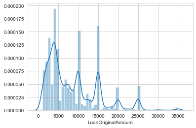

```python
# Loan Original Amount
sns.distplot(df_0['LoanOriginalAmount'])
plt.figure(figsize=(11.7,9))
```

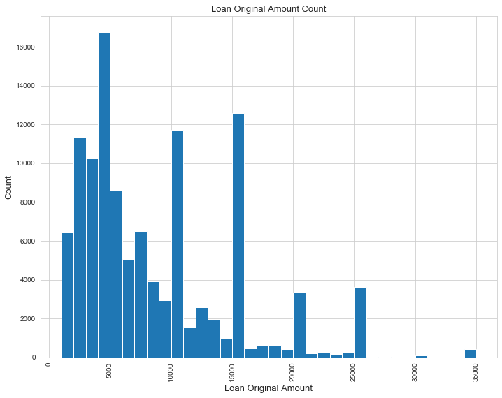

```python
ticks =np.arange(0, 36000 ,5000)
labels = ['{}'.format(v) for v in ticks]

# cut continuous to discrete variable
plt.figure(figsize=(11.7,9))
bins = np.arange(df_0['LoanOriginalAmount'].min(), df_0['LoanOriginalAmount'].max()+1000, 1000)
plt.hist(data = df_0, x = 'LoanOriginalAmount', bins = bins)
plt.xticks(ticks, labels)
plt.xticks(rotation = 90)
plt.xlabel('Loan Original Amount',fontsize=13)
plt.ylabel('Count',fontsize=13)
plt.title('Loan Original Amount Count',fontsize=13)
sns.set_context('paper')
```

-The Histrogram shows loans taken ranging from USD 1000, to USD35,000,.

-The Distribution of Loan is Skewed toward Low Loan Amount. The bulk of the count lies below $ 15,000, which indicates that most of the borrowers using Prosper are either looking for small loans or they are restricted from getting high Loan amount. I will try to find more precisely in comming sections.

-The intersting thing was that there are huge spikes in the count on round values, like USD 5,000, USD 10,000, USD 15,000, and even USD 20,000 and USD 25,000. This is obvious; people are like to pick on values that are easy to remember, like those that are factors of 5 and 10, rather than arbitrary values in between.

```python
### income ranges of number of Borrowers
```

```python
# re ordering by size
type_order_income = ["Not employed","$0","$1-24,999","$100,000+","$25,000-49,999","$50,000-74,999","$75,000-99,999","Not displayed"]
```

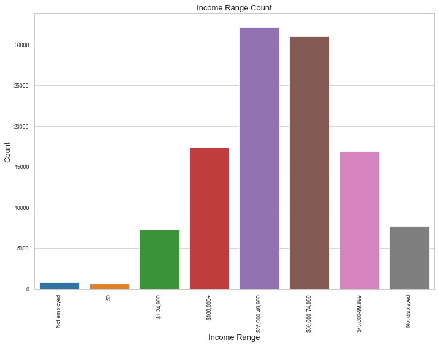

```python
# count plot on income range
# sns.set_context('poster')
plt.figure(figsize=(11.7,8.27))
sns.countplot(data = df_0, x = 'IncomeRange', order  = type_order_income)
plt.xticks(rotation = 90)
plt.xlabel('Income Range',fontsize=13)
plt.ylabel('Count',fontsize=13)
plt.title('Income Range Count',fontsize=13)

# sns.set_context("paper", rc={"axes.labelsize":10})
```

The graph resembles bell curve( normal distribution) but not very perfectly,The bulk of the data lies in that lower to middle-income region,who don't have reserve and savings and I presume such people require services such as Prosper’s the most.

```python
# Credit Score
```

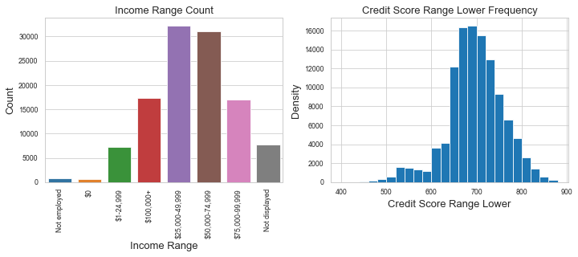

```python
fig = plt.figure(figsize=(11.69, 8.27))

ax1 = fig.add_subplot(221)
sns.countplot(data = df_0, x = 'IncomeRange', order  = type_order_income)
plt.xticks(rotation = 90)
plt.xlabel('Income Range',fontsize=13)
plt.ylabel('Count',fontsize=13)
plt.title('Income Range Count',fontsize=13)

ax2 = fig.add_subplot(222)
bins = np.arange(400, 900, 20)
df_0['CreditScoreRangeLower'].plot(kind = 'hist', bins = bins)
# sns.distplot(df_0['CreditScoreRangeLower'], hist=True, kde=True,
#              bins=bins, color = 'darkblue',
#              hist_kws={'edgecolor':'black'},
#              kde_kws={'linewidth': 1})
# plt.xlim((400, 900))
plt.xlabel('Credit Score Range Lower',fontsize=13)
plt.ylabel('Density',fontsize=13)

plt.title('Credit Score Range Lower Frequency',fontsize=13)
```

The CreditScore plot clearly shows that a majority of the users lie between the 650 and 750 mark, which are decent credit scores.The side on the right of Credit_score_range_Lower the mean looks a lot more smoother than the side on the left, and I presume that may be because of their is qualifying rule for Loan which is the minimum Credit Score required for a loan would be 640.

```python
# Comparsion of Rating Categories of Borrowers(CreditGrade’ pre-2009 rating, and ‘ProsperRating’ Post2009 )
```

```python
order_CreditGrade=['AA','A','B','C','D','E','HR']
```

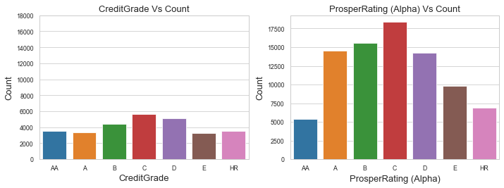

```python
fig = plt.figure(figsize=(11.69, 8.27))

ax1 = fig.add_subplot(221)
sns.countplot(data = df_0, x = 'CreditGrade',order=order_CreditGrade)
plt.xlabel('CreditGrade',fontsize=13)
plt.ylabel('Count',fontsize=13)
plt.title('CreditGrade Vs Count',fontsize=13)
plt.ylim((0, 18000))
ax2 = fig.add_subplot(222)
sns.countplot(data = df_0, x = 'ProsperRating (Alpha)',order=order_CreditGrade)
plt.xlabel('ProsperRating (Alpha)',fontsize=13)
plt.ylabel('Count',fontsize=13)
plt.title('ProsperRating (Alpha) Vs Count',fontsize=13)
```

The first important fact that goes along with this plot is that ‘CreditGrade’ is the pre-2009 rating, and ‘ProsperRating’ is the more sophisticated post-2009 rating.If you observe the scale of y-axis ‘CreditGrade’ has less values( loan Listings) than ‘ProsperRating’. This is an indication of Prosper's buisiness growth and more popularity after 2009..

The relative amounts of ‘AA’ rated loans are much less post-2009 than they were pre-2009. This Could be because of the stricter rating system Prosper implemented? Or maybe the number decreased because of the financial crisis at the time? lets see if we can get answer by the end of our analysis.

```python
#Does HomeOwner-ship have any affect on borowing pattern of Prosper Loans.
```

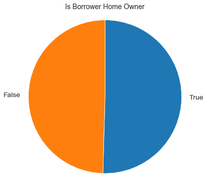

```python
plt.figure(figsize=(6,9))
sorted_count = df_0['IsBorrowerHomeowner'].value_counts()
plt.pie(sorted_count, labels= sorted_count.index, startangle=90, counterclock=False,textprops={'size': 'x-large'})
plt.axis('square')
plt.title('Is Borrower Home Owner',fontsize=14)
```

Since the graph shows their are as many ''home owner " as ''Not home Owner" borrowers, this can be concluded that home ownership has no affect on borrowing Loan from Prosper.

#### BorrowerAPR or Interest on Loans:

The Borrower's Annual Percentage Rate (APR) for the loan.It's different from the interest rate in that it not only includes interest costs, but also fees related to a loan. It tells you how much a loan will cost in one year. you can usually assume that a lower APR is better than a higher APR (with mortgages being an important exception).

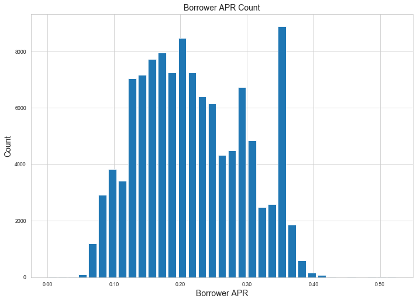

```python
plt.figure(figsize=(11.7,8.27))
ticks =list(np.arange(0, 0.6, 0.1))
labels = ['{:.2f}'.format(v) for v in ticks]
bins = np.arange(0, df_0['BorrowerAPR'].max()+.02, .015)
plt.hist(df_0['BorrowerAPR'].dropna().values, bins = bins,rwidth=0.8)
# plt.hist(data = df_0, x = 'BorrowerAPR', bins = bins)
plt.xticks(ticks, labels)
plt.xlabel('Borrower APR',fontsize=14)
plt.ylabel('Count',fontsize=14)
plt.title("Borrower APR Count",fontsize=14)
```

The bulk of the loans seem to be near the 0.2 mark, which coincides with the credit rating histograms that show that the majority of the users are in the middle of the risk ratings. There is a strange spike in the 0.35-0.37 bin which indicates a strangely popular fee rate for primarily higher risk borrowers. we will investigate this deeper in Multivariant section.

```python
# Lenders Yield ( Profit to Lender)
```

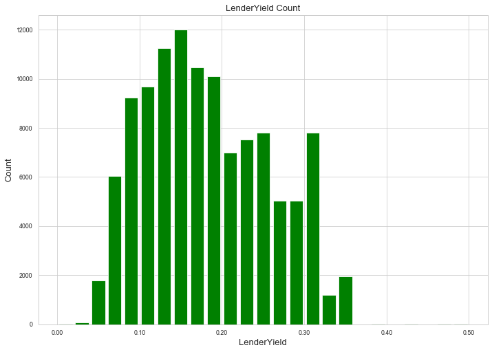

```python
plt.figure(figsize=(11.7,8.27))
ticks =list(np.arange(0, 0.6, 0.1))
labels = ['{:.2f}'.format(v) for v in ticks]
bins = np.arange(0, df_0['LenderYield'].max()+.02, .02)
plt.hist(data = df_0, x = 'LenderYield', bins = bins,color='g',rwidth=0.8)
plt.xticks(ticks, labels)

plt.xlabel('LenderYield',fontsize=13)
plt.ylabel('Count',fontsize=13)
plt.title("LenderYield Count",fontsize=13)
```

The lender yield plot is similar to borrower APR, however, that the peak count is slightly lower than the one in the borrower APR plot, that make sense because lender yield is equal to the interest rate on the loan less the servicing fee.

```python
# Debt to Income Ratio
```

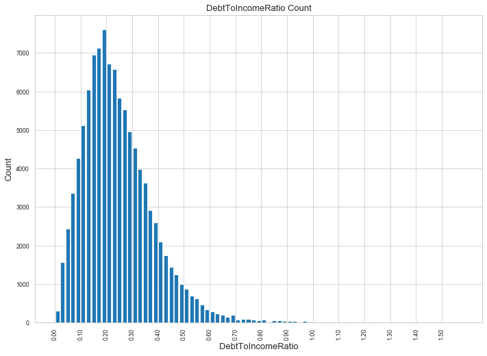

```python
plt.figure(figsize=(11.7,8.27))
ticks =list(np.arange(0, 1.6, 0.1))
labels = ['{:.2f}'.format(v) for v in ticks]
bins = np.arange(0, 1.6, .02)

plt.hist(df_0['DebtToIncomeRatio'].dropna().values, bins = bins,rwidth=0.8)
# plt.hist(data = df_0, x = 'DebtToIncomeRatio', bins = bins)
plt.xticks(ticks, labels)
plt.xticks(rotation = 90)
plt.xlabel('DebtToIncomeRatio',fontsize=13)
plt.ylabel('Count',fontsize=13)
plt.title("DebtToIncomeRatio Count",fontsize=13)
```

```python
df_0['DebtToIncomeRatio'].describe()
```

```
count    105383.000000
mean          0.275947
std           0.551759
min           0.000000
25%           0.140000
50%           0.220000
75%           0.320000
max          10.010000
Name: DebtToIncomeRatio, dtype: float64
```

The Debt to income ratio is posively skewed. Most of the borrowers have a debt-to-income ratio below 0.7, we can see the peak at DebtTo income Ratio of 0.2 .

```python
# Delinquencies
```

```python
df_d=df_0['CurrentDelinquencies'].value_counts()
df_d.index
```

```
Float64Index([ 0.0,  1.0,  2.0,  3.0,  4.0,  5.0,  6.0,  7.0,  8.0,  9.0, 10.0,
              11.0, 12.0, 13.0, 15.0, 14.0, 16.0, 17.0, 18.0, 21.0, 19.0, 20.0,
              22.0, 27.0, 24.0, 23.0, 26.0, 31.0, 25.0, 28.0, 32.0, 30.0, 36.0,
              35.0, 41.0, 40.0, 39.0, 82.0, 64.0, 33.0, 50.0, 57.0, 83.0, 51.0,
              45.0, 59.0, 37.0],
             dtype='float64')
```

```python
lo=[-1, 0.0,  1.0,  2.0,  3.0,  4.0,  5.0,  6.0,  7.0,  8.0,  9.0, 10.0,
              11.0, 12.0, 13.0, 15.0, 14.0, 16.0, 17.0, 18.0, 21.0, 19.0, 20.0,
              22.0, 27.0, 24.0, 23.0, 26.0, 31.0, 25.0, 28.0, 32.0, 30.0, 36.0,
              35.0, 41.0, 40.0, 39.0, 82.0, 64.0, 33.0, 50.0, 57.0, 83.0, 51.0,
              45.0, 59.0, 37.0]
```

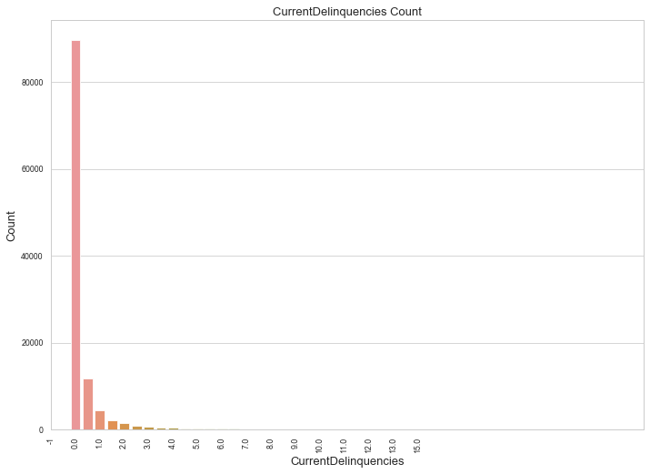

```python
plt.figure(figsize=[ 11.69, 8.27])

sns.countplot(data = df_0, x = 'CurrentDelinquencies', order=lo)
ticks =list(np.arange(-1, 30, 2))
plt.xticks(ticks, rotation = 90)
plt.xlabel('CurrentDelinquencies',fontsize=13)
plt.ylabel('Count',fontsize=13)
plt.title("CurrentDelinquencies Count",fontsize=13)
```

##### With minor exceptions almost all the borrowers have 0 current delinquencies.

```python
# Loan Status Spectrum
```

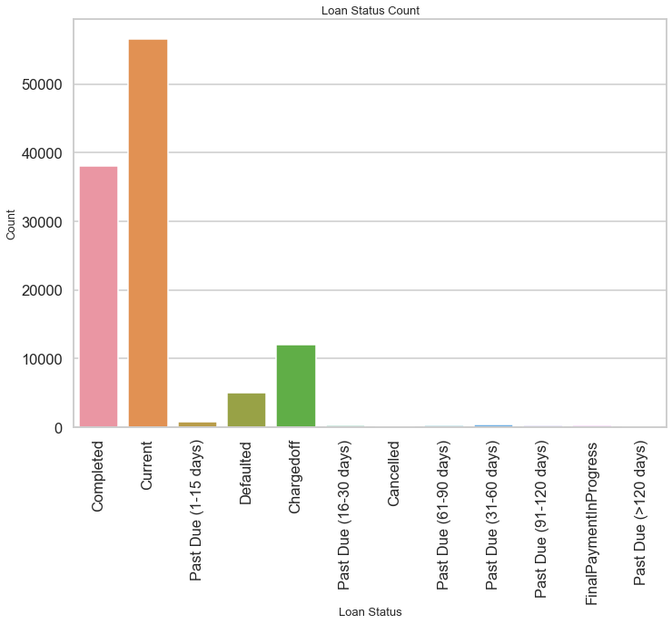

```python
# df_Loan['LoanStatus'].value_counts().plot(kind = 'bar')
# plt.xlabel('Loan Status')
# plt.ylabel('Count')
# plt.title('Loan Status Count')
plt.figure(figsize=[ 11.69, 8.27])
sns.set_context('talk')
sns.countplot(data = df_0, x = 'LoanStatus')
plt.xticks(rotation = 90)
plt.xlabel('Loan Status',fontsize=13)
plt.ylabel('Count',fontsize=13)
plt.title("Loan Status Count",fontsize=13)
```

```python
# preparing data for understanding the Prosper business growth with time
```

```python
Quater_list=df_0['LoanOriginationQuarter'].unique()
Quater_list
```

```
array(['Q3 2007', 'Q1 2014', 'Q1 2007', 'Q4 2012', 'Q3 2013', 'Q4 2013',
       'Q2 2013', 'Q2 2012', 'Q4 2007', 'Q3 2006', 'Q1 2013', 'Q2 2010',
       'Q1 2012', 'Q3 2012', 'Q4 2010', 'Q4 2011', 'Q3 2008', 'Q2 2007',
       'Q4 2006', 'Q2 2011', 'Q1 2011', 'Q1 2008', 'Q3 2009', 'Q3 2011',
       'Q2 2008', 'Q1 2010', 'Q4 2009', 'Q2 2006', 'Q3 2010', 'Q1 2006',
       'Q4 2008', 'Q4 2005', 'Q2 2009'], dtype=object)
```

```python
 order_LoanOriginationQuarter=['Q1 2006', 'Q2 2006', 'Q3 2006', 'Q4 2006','Q1 2007','Q2 2007','Q3 2007','Q4 2007','Q1 2008','Q2 2008','Q3 2008','Q4 2008','Q2 2009','Q3 2009','Q4 2009','Q1 2010','Q2 2010','Q3 2010','Q4 2010','Q1 2011','Q2 2011','Q3 2011','Q4 2011', 'Q1 2012', 'Q2 2012','Q3 2012', 'Q4 2012','Q1 2013','Q1 2014', 'Q2 2013','Q3 2013','Q4 2013','Q1 2014']
 print(order_LoanOriginationQuarter)
```

```
['Q1 2006', 'Q2 2006', 'Q3 2006', 'Q4 2006', 'Q1 2007', 'Q2 2007', 'Q3 2007', 'Q4 2007', 'Q1 2008', 'Q2 2008', 'Q3 2008', 'Q4 2008', 'Q2 2009', 'Q3 2009', 'Q4 2009', 'Q1 2010', 'Q2 2010', 'Q3 2010', 'Q4 2010', 'Q1 2011', 'Q2 2011', 'Q3 2011', 'Q4 2011', 'Q1 2012', 'Q2 2012', 'Q3 2012', 'Q4 2012', 'Q…
```

```
No handles with labels found to put in legend.
```

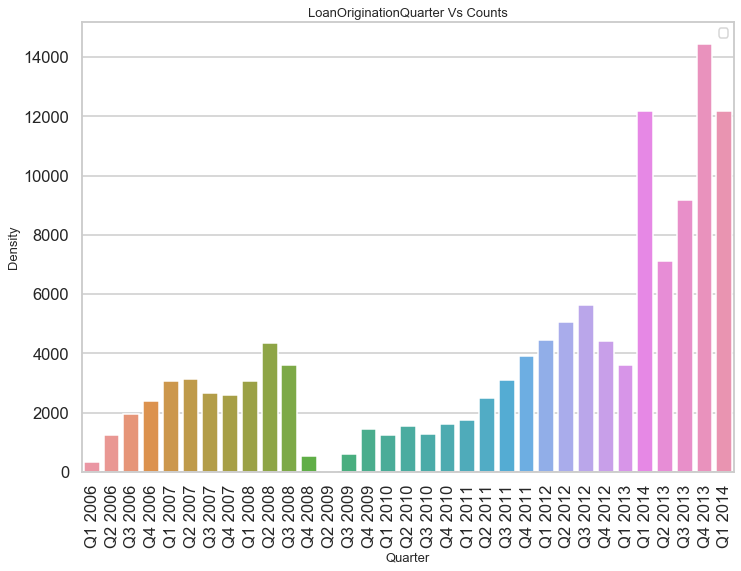

```python
plt.figure(figsize=[ 11.69, 8.27])

sns.countplot(df_0['LoanOriginationQuarter'],order=order_LoanOriginationQuarter)
# Plot formatting
plt.xticks(rotation = 90)

plt.legend(prop={'size': 12})
plt.xlabel('Quarter',fontsize=13)
plt.ylabel('Density',fontsize=13)
plt.title('LoanOriginationQuarter Vs Counts',fontsize=13)
```

We can see the steady growth in number of loans from around 300 in 2006 Q1 to about 3100 two years later in (2008 Q1) - a ten times increase. But there’s a huge slump in the end of 2008, and which continues for the next 3 quarters (there’s no data for 2009 Q1).The ‘quiet period’ ended in July 2009, which explains the 0 loans issued in 2009 Q2 (and I assume Q1 as well; there’s no data available may be because of a change in business model or reforms in Company policies.), Nevertheless we see the revival with around 500 loans in Q3 of 2009.

Post 2009, we can see the sharp rise in the number of loans that were brokered, when Prosper went from around 1200 in the beginning of 2010 to 14,400 in just a mere 4 years

```python
#  Loan Payment Status with time all Quaters(2006 to 2014)
```

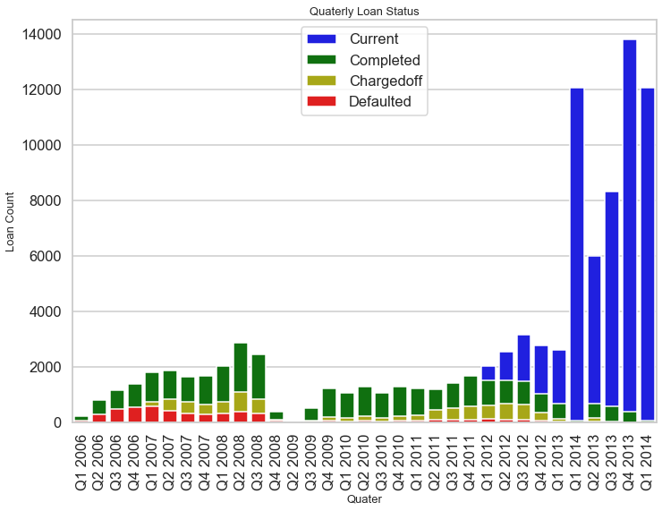

```python
## legend
figsize=[ 11.69, 8.27]
f, ax = plt.subplots(1, 1,figsize=figsize)

sns.countplot(df_0.LoanOriginationQuarter[df_0.LoanStatus=='Current'], label='Current',order=order_LoanOriginationQuarter, color='b')
sns.countplot(df_0.LoanOriginationQuarter[df_0.LoanStatus=='Completed'], label='Completed',order=order_LoanOriginationQuarter, color='g')
sns.countplot(df_0.LoanOriginationQuarter[df_0.LoanStatus=='Chargedoff'], label='Chargedoff',order=order_LoanOriginationQuarter, color='y')
sns.countplot(df_0.LoanOriginationQuarter[df_0.LoanStatus=='Defaulted'], label='Defaulted',order=order_LoanOriginationQuarter, color='r')
plt.xticks(rotation = 90)
plt.xlabel('Quater',fontsize=13)
plt.ylabel('Loan Count',fontsize=13)
plt.title('Quaterly Loan Status',fontsize=13)

ax.legend()
```

Here we can see the performance of loans over time. the Red to Yellow to Green denote a progression from worse to better, and the Blue represents ongoing (curret loans) that will either end up being completed or defaulted in the future we cannot say any thing about them now.

The decrease in number of red (defaulted borrowers) over time is indicating that Prosper is a reliable Platform for lenders here they can make money and their investments are safe. Although number of defaulting Loans are decreasing but still we cannot give a conclusion on this, since it depends on other parameter as well, we shall discover them in next sections.

### Discuss the distribution(s) of your variable(s) of interest. Were there any unusual points? Did you need to perform any transformations?

> Yes created a new column 'CreditScoreAvg' variable by taking the average of CreditScoreAvgUpper and CreditScoreAvgLower, since both follow a same trend.

> Also i performed wrangling and transformation on column 'ListingCategory (numeric)' to make a new DataFrme 'df_category(DataFrame)'

### Of the features you investigated, were there any unusual distributions? Did you perform any operations on the data to tidy, adjust, or change the form of the data? If so, why did you do this?

> Yes while plotting graph to find out the Good borrowers and Bad borrowers. I transform i.e.(scaled) my 'CurrentDelinquencies'data for better visualization and understanding.

## Bivariate Exploration

> In this section, we will further investigate relationships between pairs of variables in our data.

```python
 # Relationship between borrower’s Prosper rating and their Credit score
```

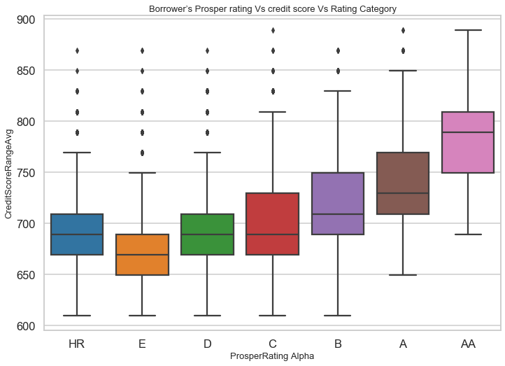

```python
order_CreditGrade=['AA','A','B','C','D','E','HR']
order_CreditGrade_reverse=reversed(order_CreditGrade)
plt.figure(figsize=( 11.69, 8.27))
sns.boxplot(data = df_0, y = 'CreditScoreRangeAvg',x = 'ProsperRating (Alpha)',order=order_CreditGrade_reverse)

plt.xlabel('ProsperRating Alpha',fontsize=13)
plt.ylabel('CreditScoreRangeAvg',fontsize=13)
plt.title('Borrower’s Prosper rating Vs credit score Vs Rating Category',fontsize=13)
# plt.xticks(rotation = 45)
```

The boxplots above shows the relationship between borrower’s Prosper rating (note - this is only post-2009 data,.Pre 2009 this was called as Credit Grade) and their CreditScore, and the variation in each rating category. A credit score is one of the key indicator of determining a person's likelihood of paying credit back, so it’s obvious that as we climb the 'Prosper rating' categories, the 'credit score' of the borrowers also tend to increase.

Strange thing to notice is ‘HR’ prosper rating has a slightly higher median and IQR than ‘E’ despite being a riskier category - in fact, it’s on par with borrowers with a ‘D’ rating.May be this is because HR category People have a higher penality on Non-Payments that keeps them on toes.

### Credit Score is one of the factors of Prosper’s rating categories. These categories, along with some other financial information, determine the Annual Percentage Rate (interest+ Fee overheads) that will apply to the borrower’s loan.

So let’s see how the APR changes as the categories get less risky:

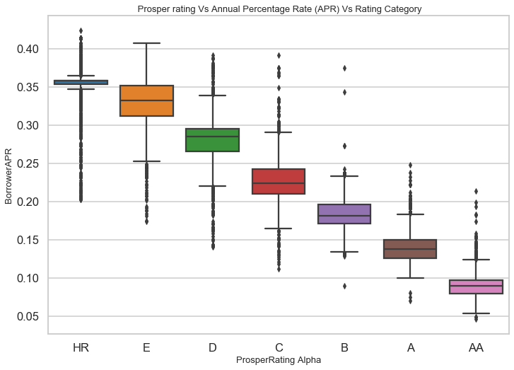

```python
plt.figure(figsize=(11.69, 8.27))
order_CreditGrade_reverse=reversed(order_CreditGrade)

sns.boxplot(data = df_0, y = 'BorrowerAPR', x = 'ProsperRating (Alpha)',order=order_CreditGrade_reverse)

plt.xlabel('ProsperRating Alpha',fontsize=13)
plt.ylabel('BorrowerAPR',fontsize=13)
plt.title(' Prosper rating Vs Annual Percentage Rate (APR) Vs Rating Category',fontsize=13)
```

As we move from High risk to lower risk (Prosper Rating) i.e. - from a ‘HR’ to an ‘AA’ rating - the APR for the borrower reduces drastically. In fact, looking at the results, it goes from a median APR of 35% for High Risk all the way to a median value of 9% for ‘AA’.

-The surprising thing is 'High Risk' has most consistent APR af all other Prosper rating categories.

There is also a reduction in the number of outliers, which is visible by the shortening lines of black dots as we move toward less riskier rating.

```python
#  Further Investigation on 'number of loans that were defaulted' over time.
```

```python
#Data Filtering for defaulted Loans

df_loan_defaulted=df_0[df_0.LoanStatus=='Defaulted']
df_loan_defaulted.head()
```

|  | ListingKey | ListingNumber | ListingCreationDate | CreditGrade | Term | LoanStatus | ClosedDate | BorrowerAPR | BorrowerRate | LenderYield | EstimatedEffectiveYield | EstimatedLoss | EstimatedReturn | ProsperRating (numeric) | ProsperRating (Alpha) | ProsperScore | ListingCategory | BorrowerState | Occupation | EmploymentStatus | EmploymentStatusDuration | IsBorrowerHomeowner | CurrentlyInGroup | GroupKey | DateCreditPulled | CreditScoreRangeLower | CreditScoreRangeUpper | FirstRecordedCreditLine | CurrentCreditLines | … |
| --- | --- | --- | --- | --- | --- | --- | --- | --- | --- | --- | --- | --- | --- | --- | --- | --- | --- | --- | --- | --- | --- | --- | --- | --- | --- | --- | --- | --- | --- | --- |
| 15 | 0F483544120452347F48121 | 577164 | 2012-04-10 09:14:46.297000000 | NaN | 36 | Defaulted | 2012-12-19 00:00:00 | 0.35797 | 0.3177 | 0.3077 | 0.2896 | 0.1650 | 0.1246 | 1.0 | HR | 5.0 | Household | FL | Other | Other | 121.0 | True | False | NaN | 2012-04-10 09:14:41 | 700.0 | 719.0 | 1999-03-08 00:00:00 | 10.0 | … |
| 23 | 101B35764008108187B2EBA | 758964 | 2013-04-22 13:29:19.073000000 | NaN | 36 | Defaulted | 2013-12-26 00:00:00 | 0.28032 | 0.2419 | 0.2319 | 0.2126 | 0.1075 | 0.1051 | 3.0 | D | 5.0 | Medical | IL | Skilled Labor | Employed | 3.0 | False | False | NaN | 2013-04-22 13:29:14 | 680.0 | 699.0 | 1998-06-09 00:00:00 | 7.0 | … |
| 107 | 10BE354254173728633D033 | 573446 | 2012-03-29 12:17:10.017000000 | NaN | 36 | Defaulted | 2012-12-23 00:00:00 | 0.35797 | 0.3177 | 0.3077 | 0.2896 | 0.1650 | 0.1246 | 1.0 | HR | 2.0 | Debt | OH | Administrative Assistant | Employed | 84.0 | False | False | NaN | 2012-03-29 12:17:03 | 720.0 | 739.0 | 1987-03-01 00:00:00 | 16.0 | … |
| 128 | 110A3373894473317F98123 | 57371 | 2006-11-05 12:48:42.960000000 | HR | 36 | Defaulted | 2007-11-14 00:00:00 | 0.18824 | 0.1700 | 0.1250 | NaN | NaN | NaN | NaN | NaN | NaN | Unknown | FL | Other | Not available | NaN | True | True | 783C3371218786870A73D20 | 2006-11-02 16:38:08.390000000 | 500.0 | 519.0 | 1991-07-01 00:00:00 | NaN | … |
| 138 | 11273541569159931E84F17 | 569000 | 2012-03-16 09:22:33.393000000 | NaN | 36 | Defaulted | 2012-09-20 00:00:00 | 0.33973 | 0.2999 | 0.2899 | 0.2766 | 0.1490 | 0.1276 | 2.0 | E | 3.0 | Auto | KY | Military Enlisted | Employed | 126.0 | True | False | NaN | 2012-03-06 11:00:20 | 620.0 | 639.0 | 2001-04-20 00:00:00 | 7.0 | … |

5 rows × 82 columns

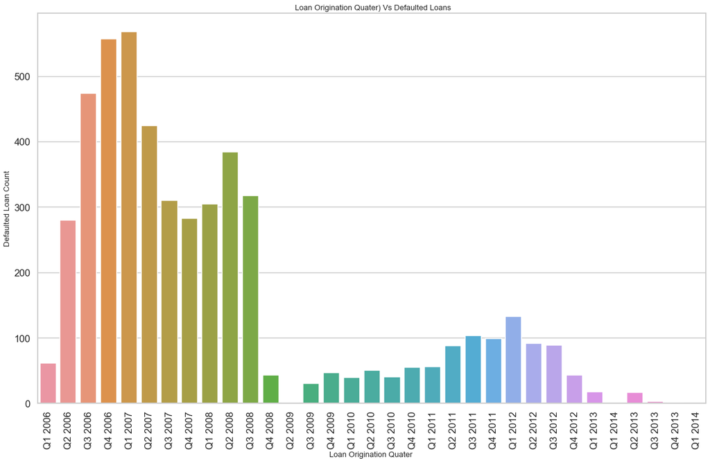

```python
plt.figure(figsize=(20,12))

sns.countplot(df_0.LoanOriginationQuarter[df_0.LoanStatus=='Defaulted'],order=order_LoanOriginationQuarter)
plt.xticks(rotation = 90)

plt.xlabel('Loan Origination Quater ',fontsize=13)
plt.ylabel('Defaulted Loan Count',fontsize=13)
plt.title(' Loan Origination Quater) Vs Defaulted Loans',fontsize=13)
```

The number of defaulters in each year are shown with the help of bars in plot above This is a very important parameter for Prosper Platform because it helps in determining the frequency of bad loans, It also helps to judge whether any policies - like the 'minimum credit score' - are improving the likelihood of payment.

The defaulters count drops to zero twice over the period.

-The first is because of the ‘quiet’ period in 2009 as mentioned before, and therefore drop is expected.

-The second 'quiet period' was in 2013, because most of the loans in that period are in the ‘Current’ or in ‘FinalPaymentInProgress’ status, and there just hasn’t been enough time to know whether loans are ‘Completed’ or ‘Defaulted’. Over time, that 'defaulter bars' may go higher but at the moment we are unable to give any concluding remarks .

```python
#  Relationship between Employment Status Vs the amount borrowers were delinquent Vs Number of Delinquencies they’ve had over the last 7 years.
```

```python
# sns.distplot(df_Loan.LoanOriginationQuarter[df_Loan.LoanStatus=='Defaulted'])
df_status_Employment=df_0[(df_0.EmploymentStatus == 'Employed')|(df_0.EmploymentStatus == 'Retired')|(df_0.EmploymentStatus == 'Self-employed')|(df_0.EmploymentStatus == 'Part-time')|(df_0.EmploymentStatus == 'Not available')|(df_0.EmploymentStatus == 'Full-time')]
df_0.EmploymentStatus.unique()
```

```
array(['Self-employed', 'Employed', 'Not available', 'Full-time', 'Other',
       nan, 'Not employed', 'Part-time', 'Retired'], dtype=object)
```

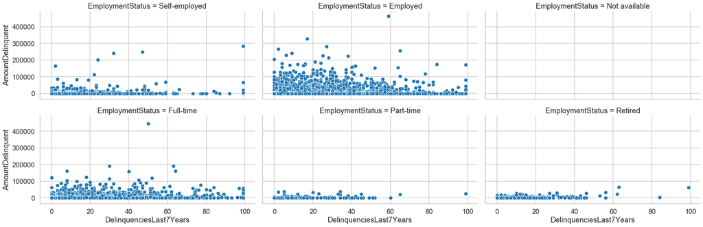

```python
g = sns.FacetGrid(df_status_Employment, col="EmploymentStatus",size=4,col_wrap=3, height=5, aspect=2)
g.map(sns.scatterplot, "DelinquenciesLast7Years", "AmountDelinquent");
```

I had generated Seperate graphs on basis of various employment status to understand if people that weren’t 'full time employed' had higher delinquencies or owed more money?

-This may not be case that 'unemployed' , 'retired' , 'part time worker' manage their Loan well or are responsible with their payment , it may be owing to the reason Prosper have a stricter rule to grant them Loans.

### Talk about some of the relationships you observed in this part of the investigation. How did the feature(s) of interest vary with other features in the dataset?

> 'credit score' is one of the key indicator of determining a person's paying back their Loans, we visualize the relationship between both 'credit score' and 'Prosper Rating', our graph also made it obvious that as we climb the rating categories from 'HR' to 'AA', the credit score of the borrowers also tend to increase. yes feature of interst vary with dataset such that out-liers in 'creditScoreRangeAvg' begin to decrease as rating climbs higher to AA.

### Did you observe any interesting relationships between the other features (not the main feature(s) of interest)?

> While studying relationship between BrowerAPR Vs Prosper Ratings surprising thing is 'High Risk' has most consistent BorrowerAPR of all other Prosper rating categories even more consitent then AA rating.

## Multivariate Exploration

```python
# 'Debt to Income Ratio' Vs 'credit score Range ' Vs 'Defaulter ' and 'Completed Loans'
```

```python
# Selecting a Dataset containg only records that are not ongoing loan( either they are completed or Defaulted)

df_Endstatus=df_0[(df_0.LoanStatus == 'Completed')|(df_0.LoanStatus == 'Defaulted')]
df_Endstatus
```

|  | ListingKey | ListingNumber | ListingCreationDate | CreditGrade | Term | LoanStatus | ClosedDate | BorrowerAPR | BorrowerRate | LenderYield | EstimatedEffectiveYield | EstimatedLoss | EstimatedReturn | ProsperRating (numeric) | ProsperRating (Alpha) | ProsperScore | ListingCategory | BorrowerState | Occupation | EmploymentStatus | EmploymentStatusDuration | IsBorrowerHomeowner | CurrentlyInGroup | GroupKey | DateCreditPulled | CreditScoreRangeLower | CreditScoreRangeUpper | FirstRecordedCreditLine | CurrentCreditLines | … |
| --- | --- | --- | --- | --- | --- | --- | --- | --- | --- | --- | --- | --- | --- | --- | --- | --- | --- | --- | --- | --- | --- | --- | --- | --- | --- | --- | --- | --- | --- | --- |
| 0 | 1021339766868145413AB3B | 193129 | 2007-08-26 19:09:29.263000000 | C | 36 | Completed | 2009-08-14 00:00:00 | 0.16516 | 0.1580 | 0.1380 | NaN | NaN | NaN | NaN | NaN | NaN | Unknown | CO | Other | Self-employed | 2.0 | True | True | NaN | 2007-08-26 18:41:46.780000000 | 640.0 | 659.0 | 2001-10-11 00:00:00 | 5.0 | … |
| 2 | 0EE9337825851032864889A | 81716 | 2007-01-05 15:00:47.090000000 | HR | 36 | Completed | 2009-12-17 00:00:00 | 0.28269 | 0.2750 | 0.2400 | NaN | NaN | NaN | NaN | NaN | NaN | Unknown | GA | Other | Not available | NaN | False | True | 783C3371218786870A73D20 | 2007-01-02 14:09:10.060000000 | 480.0 | 499.0 | 2002-07-27 00:00:00 | NaN | … |
| 11 | 0F1734025150298088A5F2B | 213551 | 2007-10-09 20:28:33.640000000 | C | 36 | Completed | 2008-01-07 00:00:00 | 0.15033 | 0.1325 | 0.1225 | NaN | NaN | NaN | NaN | NaN | NaN | Unknown | NaN | Waiter/Waitress | Full-time | 19.0 | False | False | NaN | 2007-10-08 13:13:44.363000000 | 640.0 | 659.0 | 2000-11-13 00:00:00 | 2.0 | … |
| 15 | 0F483544120452347F48121 | 577164 | 2012-04-10 09:14:46.297000000 | NaN | 36 | Defaulted | 2012-12-19 00:00:00 | 0.35797 | 0.3177 | 0.3077 | 0.2896 | 0.1650 | 0.1246 | 1.0 | HR | 5.0 | Household | FL | Other | Other | 121.0 | True | False | NaN | 2012-04-10 09:14:41 | 700.0 | 719.0 | 1999-03-08 00:00:00 | 10.0 | … |
| 21 | 1017340630713945364DA6B | 241498 | 2007-11-30 20:33:49.227000000 | D | 36 | Completed | 2010-12-12 00:00:00 | 0.21488 | 0.2075 | 0.1975 | NaN | NaN | NaN | NaN | NaN | NaN | Unknown | MI | Professional | Full-time | 36.0 | False | True | 6C2E3384236387493493CB6 | 2007-11-11 14:24:41.350000000 | 620.0 | 639.0 | 2003-06-20 00:00:00 | 4.0 | … |
| ... | ... | ... | ... | ... | ... | ... | ... | ... | ... | ... | ... | ... | ... | ... | ... | ... | ... | ... | ... | ... | ... | ... | ... | ... | ... | ... | ... | ... | ... | … |
| 113926 | E34333654295683286C35C2 | 28121 | 2006-08-01 10:31:31.143000000 | E | 36 | Defaulted | 2007-09-06 00:00:00 | 0.29776 | 0.2900 | 0.2850 | NaN | NaN | NaN | NaN | NaN | NaN | Unknown | CA | Other | Not available | NaN | False | False | NaN | 2006-08-01 10:10:42.370000000 | 540.0 | 559.0 | 1996-03-26 00:00:00 | NaN | … |
| 113927 | E3433419834735803891976 | 322787 | 2008-04-30 21:25:19.670000000 | AA | 36 | Completed | 2011-05-09 00:00:00 | 0.07469 | 0.0679 | 0.0579 | NaN | NaN | NaN | NaN | NaN | NaN | Personal | WA | Executive | Full-time | 69.0 | True | True | D1413413671123312FAD936 | 2008-04-30 21:20:54.587000000 | 760.0 | 779.0 | 1972-09-09 00:00:00 | 10.0 | … |
| 113928 | E34935176664905343E01EA | 510097 | 2011-06-06 19:02:44.443000000 | NaN | 36 | Completed | 2011-09-19 00:00:00 | 0.22362 | 0.1899 | 0.1799 | 0.1757 | 0.0610 | 0.1147 | 4.0 | C | 6.0 | Business | CO | Other | Full-time | 22.0 | False | False | NaN | 2011-06-03 16:06:00 | 740.0 | 759.0 | 2004-06-06 00:00:00 | 4.0 | … |
| 113929 | E3553583161337791FCB87F | 830413 | 2013-07-06 17:40:01.657000000 | NaN | 36 | Completed | 2014-02-07 00:00:00 | 0.30285 | 0.2639 | 0.2539 | 0.2318 | 0.1225 | 0.1093 | 2.0 | E | 3.0 | Reno | FL | Accountant/CPA | Employed | 25.0 | False | False | NaN | 2013-07-06 17:39:52 | 660.0 | 679.0 | 2008-11-17 00:00:00 | 7.0 | … |
| 113935 | E6EB3531504622671970D9E | 539056 | 2011-11-14 13:18:26.597000000 | NaN | 60 | Completed | 2013-08-13 00:00:00 | 0.28408 | 0.2605 | 0.2505 | 0.2445 | 0.0850 | 0.1595 | 4.0 | C | 5.0 | Reno | GA | Food Service | Full-time | 94.0 | True | False | NaN | 2011-11-14 13:18:24 | 680.0 | 699.0 | 1993-12-01 00:00:00 | 11.0 | … |

43092 rows × 82 columns

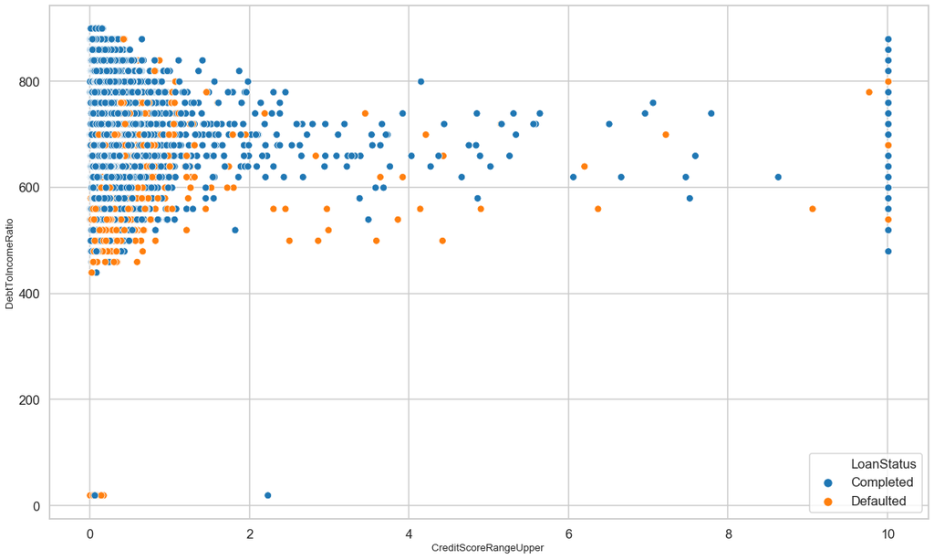

```python
plt.figure(figsize=(20,12))

sns.scatterplot(x="DebtToIncomeRatio", y="CreditScoreRangeUpper",hue="LoanStatus", data=df_Endstatus)
plt.xlabel('CreditScoreRangeUpper ',fontsize=13)
plt.ylabel('DebtToIncomeRatio',fontsize=13)
```

From the above overplotted scatterplot its difficult to decipher trend. but one thing could be clearly found among defaulters i.e. they have lower credit scores - around 600 and below - displayed by the sea of Orange dots.

-Above 600 'credit scoreRange' it seems mostly blue the completed Loans.

```python
#BorrowerAPR Vs DebtoIncomeRation Vs ProsperRating
```

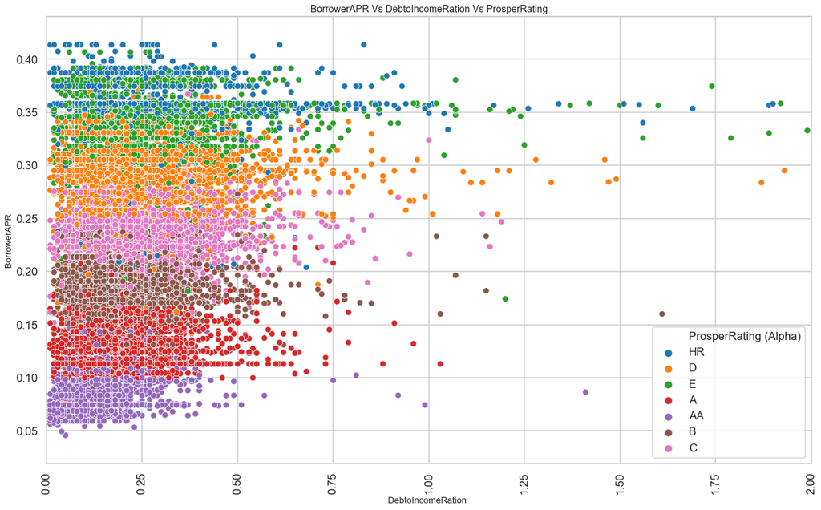

```python
plt.figure(figsize=(20,12))

sns.scatterplot(x="DebtToIncomeRatio", y="BorrowerAPR",hue="ProsperRating (Alpha)", data=df_Endstatus)
plt.xlim(0, 2)

plt.xticks(rotation = 90)
plt.title('BorrowerAPR Vs DebtoIncomeRation Vs ProsperRating',fontsize=14)
plt.xlabel('DebtoIncomeRation ',fontsize=13)
plt.ylabel('BorrowerAPR',fontsize=13)
```

This Scatter plot have a loads of datapoints and contains lot of information, the invesitigation seem difficult but if we start from the highest Prosper rating category i.e. ‘AA’ category loans it seems to have a lower APRs and a smaller range of debt-to-income ratios, both of which indicate less risk . Similarly BorrowerAPR increase as the Category move to High Risky category of 'ProperRating'.

Another intersting thing is 'debt-to-income ratios' , which is below 1 for most of the risk categories but an unusual horizontal line made by the high risk categories ‘HR’ and 'E' around 0.35APR that extends past 1 and all the way to 1.5, while lower risk ratings tend to be sparse in the 1.0+ debt-to-income ratio range.

```python
 # Relationship between lender yield VS loan status Vs amount that a borrower has loaned Vs ProsperRating
# further investigation from the Univariate Section
```

```python
# Data Preprationg for loan_status_group
df_0['LoanStatus'].unique()
```

[output not shown]

```python
# transforming our Dataset i.e. grouping all Past Due Date categories in to one
df_Loan_status_Group=df_0
df_Loan_status_Group['LoanStatus'] = df_0['LoanStatus'].replace(['Past Due (1-15 days)','Past Due (16-30 days)','Past Due (61-90 days)','Past Due (31-60 days)','Past Due (91-120 days)','Past Due (>120 days)'],'Past Due')
```

```python
df_Loan_status_Group['LoanStatus'].unique()
```

```
array(['Completed', 'Current', 'Past Due', 'Defaulted', 'Chargedoff',
       'Cancelled', 'FinalPaymentInProgress'], dtype=object)
```

```python
df_Loan_status_Group_4=df_Loan_status_Group[(df_0.LoanStatus == 'Completed')|(df_0.LoanStatus == 'Defaulted')|(df_0.LoanStatus == 'Current')|(df_0.LoanStatus == 'Past Due')]
df_Loan_status_Group_4
```

|  | ListingKey | ListingNumber | ListingCreationDate | CreditGrade | Term | LoanStatus | ClosedDate | BorrowerAPR | BorrowerRate | LenderYield | EstimatedEffectiveYield | EstimatedLoss | EstimatedReturn | ProsperRating (numeric) | ProsperRating (Alpha) | ProsperScore | ListingCategory | BorrowerState | Occupation | EmploymentStatus | EmploymentStatusDuration | IsBorrowerHomeowner | CurrentlyInGroup | GroupKey | DateCreditPulled | CreditScoreRangeLower | CreditScoreRangeUpper | FirstRecordedCreditLine | CurrentCreditLines | … |
| --- | --- | --- | --- | --- | --- | --- | --- | --- | --- | --- | --- | --- | --- | --- | --- | --- | --- | --- | --- | --- | --- | --- | --- | --- | --- | --- | --- | --- | --- | --- |
| 0 | 1021339766868145413AB3B | 193129 | 2007-08-26 19:09:29.263000000 | C | 36 | Completed | 2009-08-14 00:00:00 | 0.16516 | 0.1580 | 0.1380 | NaN | NaN | NaN | NaN | NaN | NaN | Unknown | CO | Other | Self-employed | 2.0 | True | True | NaN | 2007-08-26 18:41:46.780000000 | 640.0 | 659.0 | 2001-10-11 00:00:00 | 5.0 | … |
| 1 | 10273602499503308B223C1 | 1209647 | 2014-02-27 08:28:07.900000000 | NaN | 36 | Current | NaN | 0.12016 | 0.0920 | 0.0820 | 0.07960 | 0.0249 | 0.05470 | 6.0 | A | 7.0 | Reno | CO | Professional | Employed | 44.0 | False | False | NaN | 2014-02-27 08:28:14 | 680.0 | 699.0 | 1996-03-18 00:00:00 | 14.0 | … |
| 2 | 0EE9337825851032864889A | 81716 | 2007-01-05 15:00:47.090000000 | HR | 36 | Completed | 2009-12-17 00:00:00 | 0.28269 | 0.2750 | 0.2400 | NaN | NaN | NaN | NaN | NaN | NaN | Unknown | GA | Other | Not available | NaN | False | True | 783C3371218786870A73D20 | 2007-01-02 14:09:10.060000000 | 480.0 | 499.0 | 2002-07-27 00:00:00 | NaN | … |
| 3 | 0EF5356002482715299901A | 658116 | 2012-10-22 11:02:35.010000000 | NaN | 36 | Current | NaN | 0.12528 | 0.0974 | 0.0874 | 0.08490 | 0.0249 | 0.06000 | 6.0 | A | 9.0 | Motorcycle | GA | Skilled Labor | Employed | 113.0 | True | False | NaN | 2012-10-22 11:02:32 | 800.0 | 819.0 | 1983-02-28 00:00:00 | 5.0 | … |
| 4 | 0F023589499656230C5E3E2 | 909464 | 2013-09-14 18:38:39.097000000 | NaN | 36 | Current | NaN | 0.24614 | 0.2085 | 0.1985 | 0.18316 | 0.0925 | 0.09066 | 3.0 | D | 4.0 | Reno | MN | Executive | Employed | 44.0 | True | False | NaN | 2013-09-14 18:38:44 | 680.0 | 699.0 | 2004-02-20 00:00:00 | 19.0 | … |
| ... | ... | ... | ... | ... | ... | ... | ... | ... | ... | ... | ... | ... | ... | ... | ... | ... | ... | ... | ... | ... | ... | ... | ... | ... | ... | ... | ... | ... | ... | … |
| 113931 | E36F36005339663245C20F8 | 1141292 | 2014-01-16 20:13:08.040000000 | NaN | 60 | Current | NaN | 0.15016 | 0.1274 | 0.1174 | 0.11210 | 0.0424 | 0.06970 | 5.0 | B | 6.0 | Business | IL | Analyst | Employed | 12.0 | False | False | NaN | 2014-01-03 10:17:23 | 800.0 | 819.0 | 1975-05-01 00:00:00 | 13.0 | … |
| 113932 | E6D9357655724827169606C | 753087 | 2013-04-14 05:55:02.663000000 | NaN | 36 | Current | NaN | 0.22354 | 0.1864 | 0.1764 | 0.16490 | 0.0699 | 0.09500 | 4.0 | C | 5.0 | Debt | IL | Food Service Management | Employed | 246.0 | True | False | NaN | 2013-04-14 05:54:58 | 700.0 | 719.0 | 1997-09-01 00:00:00 | 9.0 | … |
| 113934 | E6E13596170052029692BB1 | 1069178 | 2013-12-13 05:49:12.703000000 | NaN | 60 | Current | NaN | 0.23984 | 0.2150 | 0.2050 | 0.18828 | 0.1025 | 0.08578 | 3.0 | D | 3.0 | Debt | TX | Other | Employed | 84.0 | True | False | NaN | 2013-12-13 05:49:15 | 700.0 | 719.0 | 2002-02-25 00:00:00 | 12.0 | … |
| 113935 | E6EB3531504622671970D9E | 539056 | 2011-11-14 13:18:26.597000000 | NaN | 60 | Completed | 2013-08-13 00:00:00 | 0.28408 | 0.2605 | 0.2505 | 0.24450 | 0.0850 | 0.15950 | 4.0 | C | 5.0 | Reno | GA | Food Service | Full-time | 94.0 | True | False | NaN | 2011-11-14 13:18:24 | 680.0 | 699.0 | 1993-12-01 00:00:00 | 11.0 | … |
| 113936 | E6ED3600409833199F711B7 | 1140093 | 2014-01-15 09:27:37.657000000 | NaN | 36 | Current | NaN | 0.13189 | 0.1039 | 0.0939 | 0.09071 | 0.0299 | 0.06081 | 6.0 | A | 7.0 | Debt | NY | Professor | Employed | 244.0 | False | False | NaN | 2014-01-15 09:27:40 | 680.0 | 699.0 | 1995-01-01 00:00:00 | 10.0 | … |

101735 rows × 82 columns

[figure not shown]

```python
g = sns.FacetGrid(df_Loan_status_Group_4, hue="ProsperRating (Alpha)",col="LoanStatus",col_wrap=2, height=5, aspect=1)

g.map(sns.scatterplot, "LoanOriginalAmount", "LenderYield");
plt.ylim(0, 0.4)
plt.legend(["AA","A","B","C","D","E","HR"])
# plt.title('lender yield VS loan status Vs amount that a borrower has loaned Vs ProsperRating')
```

##### This plot shows the relationship between a lender yield on the loan and the amount that a borrower has loaned.

```python
### individual graphs to show that relationship based on the status of the loan - Defaulted, Past Due, Current and Completed -
```

```python
df_status_Completed=df_0[(df_0['LoanStatus'] == 'Completed')]
df_status_Defaulted=df_0[(df_0['LoanStatus'] == 'Defaulted')]
```

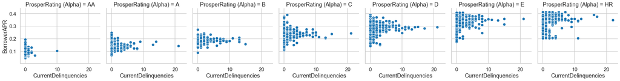

[figure not shown]

```python
g = sns.FacetGrid(df_status_Completed, hue="LoanStatus",col="ProsperRating (Alpha)",size = 4,col_wrap=7, height=5, aspect=1,col_order=["AA","A","B","C","D","E","HR"] )
g.map(sns.scatterplot, "CurrentDelinquencies", "BorrowerAPR");
g = sns.FacetGrid(df_status_Defaulted, hue="LoanStatus",col="ProsperRating (Alpha)",size = 4,col_wrap=7, height=5, aspect=1,col_order=["AA","A","B","C","D","E","HR"])
g.map(sns.scatterplot, "CurrentDelinquencies", "BorrowerAPR",color="r");
plt.legend(['Completed','Defaulted'])
```

These scatter plot show no major differences in terms of 'complete' and 'defaulting' loans staus. However, I do notice that higher rated (like 'AA')loans are less diverse in terms of 'delinquencies' and 'BorrowAPR', and customarily lumped in the bottom left corner.

As the loan gets riskier,'BorrowAPR' increases and the points on plots get more varied and diverse, and tend to be all over the plots.

### Talk about some of the relationships you observed in this part of the investigation. Were there features that strengthened each other in terms of looking at your feature(s) of interest?

> after analyzing various Loan status in scater plot we descover that Prosper Loan system discourages Risky categories'Prosper Rating' by asking higher 'BorrowAPR' for Risky categories, also it was observed that risky categories have limitations on 'orignal borrowing amount'.

### Were there any interesting or surprising interactions between features?

> 2) In creditRangeupper Vs DebttoIncome Ratio scatter plot we see a disctint line of points at a DebttoIncome Ratio of 10 here we can see completed loans mostly.this a contrasting pattern to low end of the debt to income ratio, and center portion of the scatter plot have very less points.